# STA Climate Change – Biannual Traffic Surveys

[figure not shown]

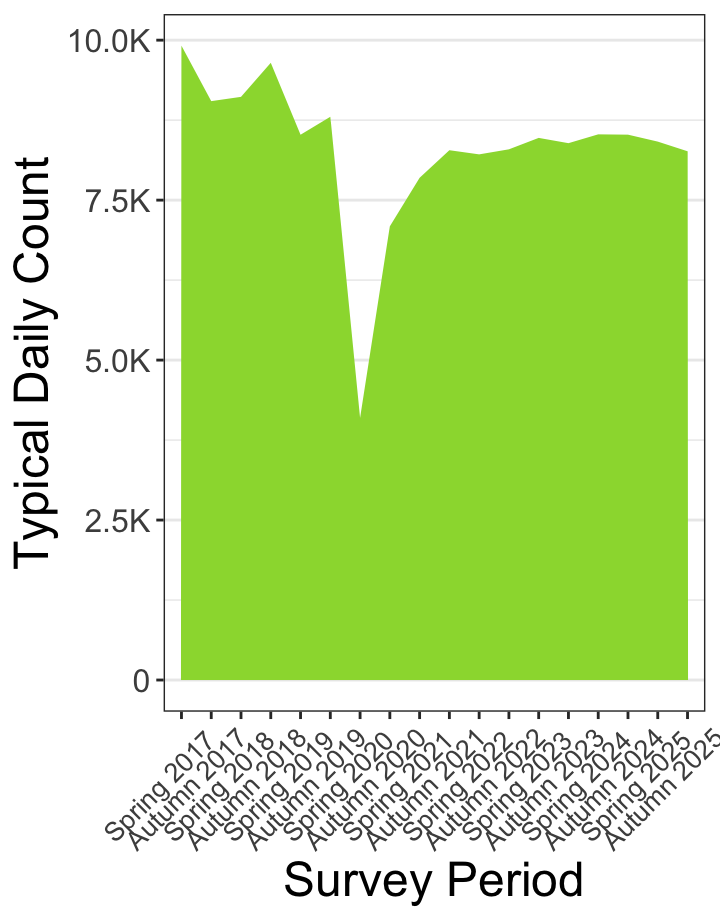

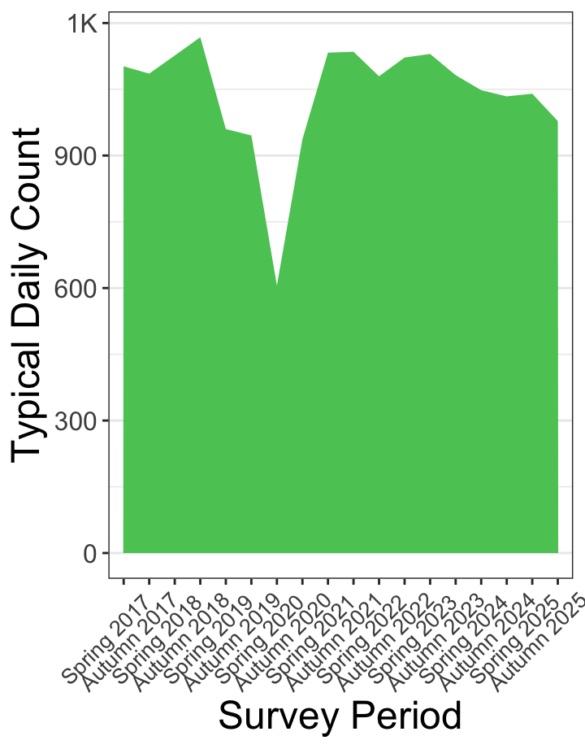

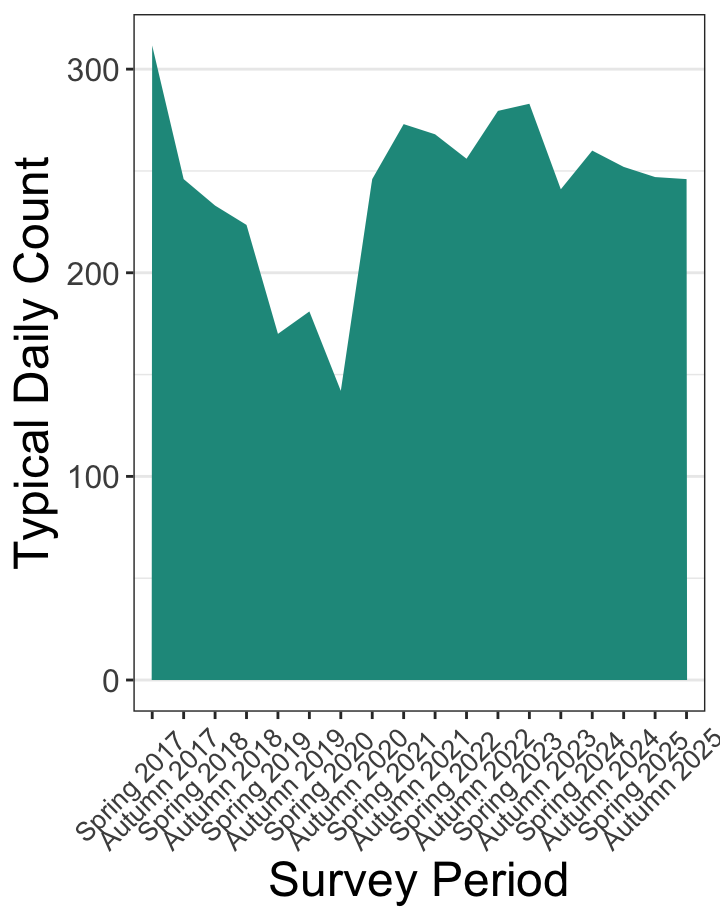

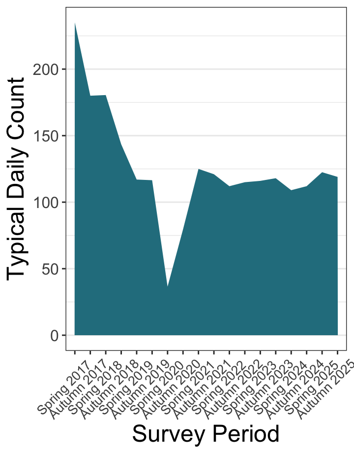

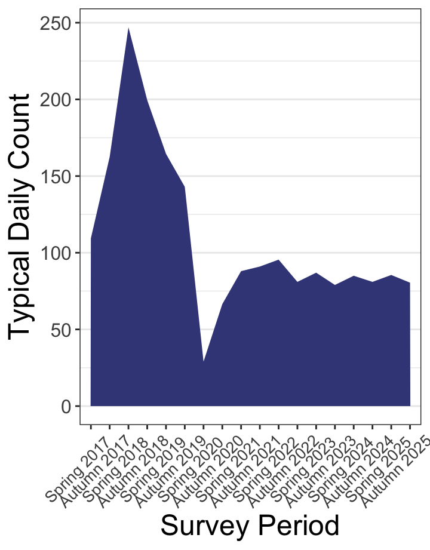

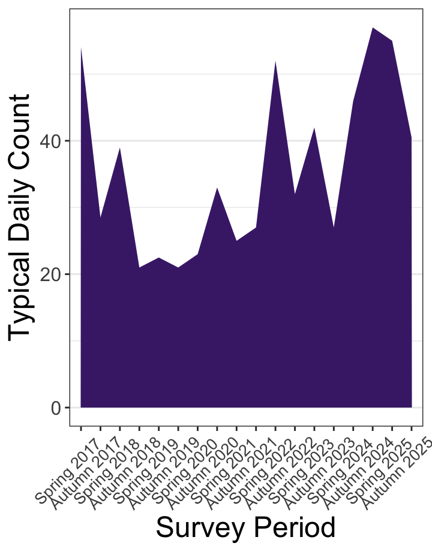

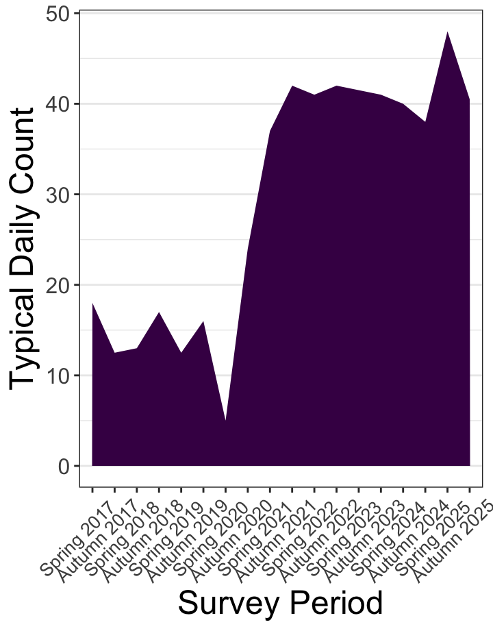

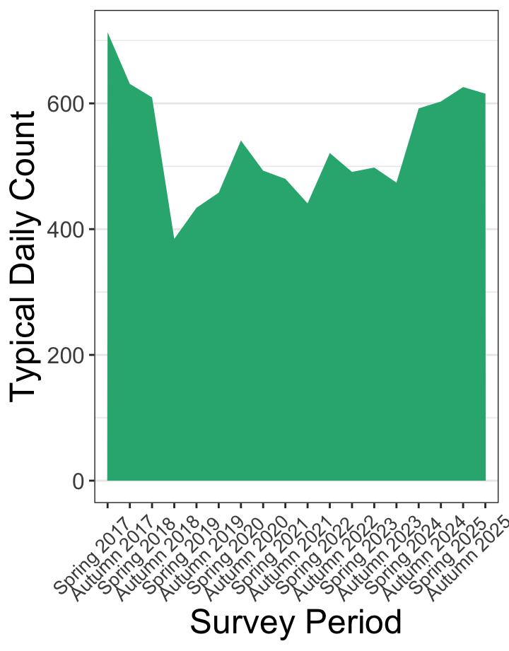

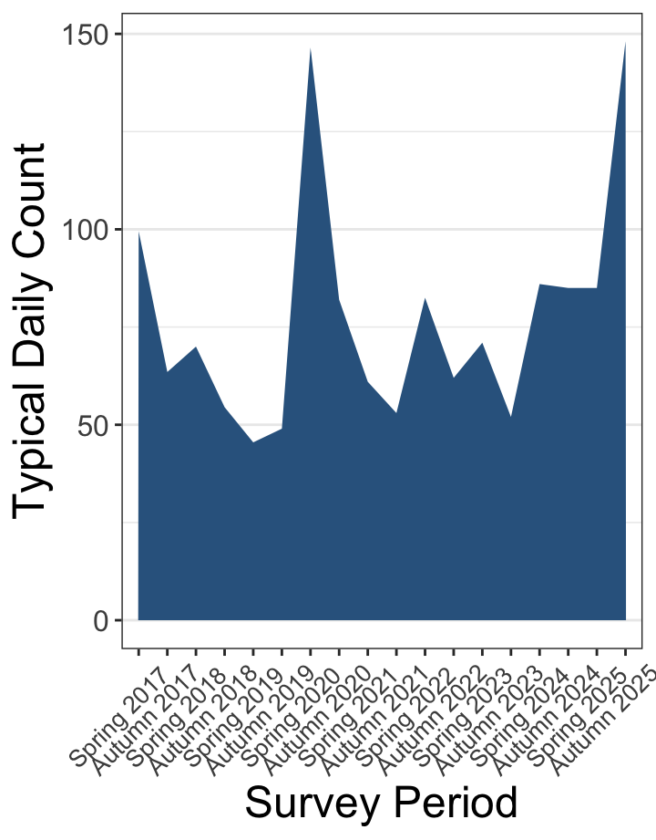

[figure not shown]

[figure not shown]

[13 more figures not shown]

# Overview

### Biannual Traffic Surveys from May 2017 to Oct 2025.

### All Transportation Modes

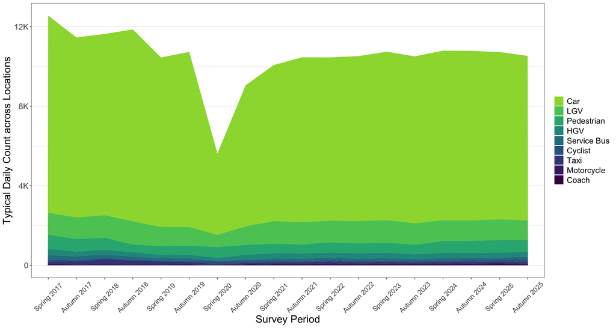

### Cycling

[interactive chart not shown]

### **Traffic counts by mode and type (motorised bs. active). The highest (typical daily) counts are furthest left, decreasing to the right.**

Motor Vehicles

Active Travel

### Car

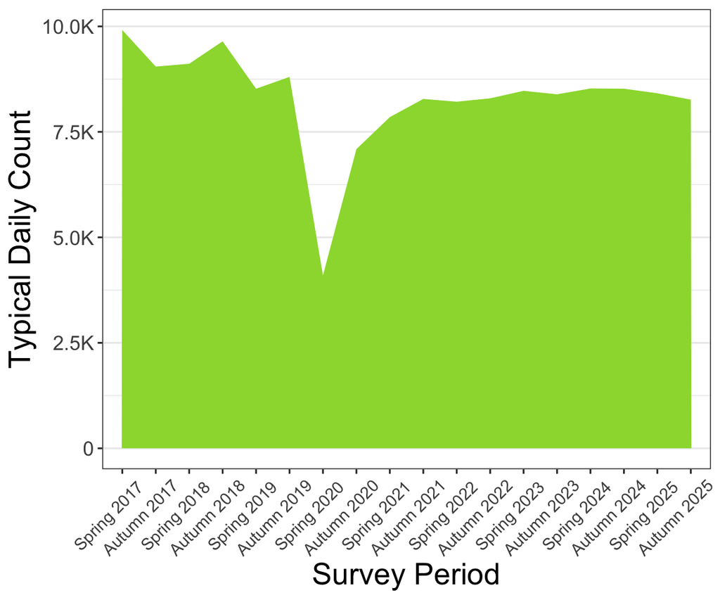

### LGV

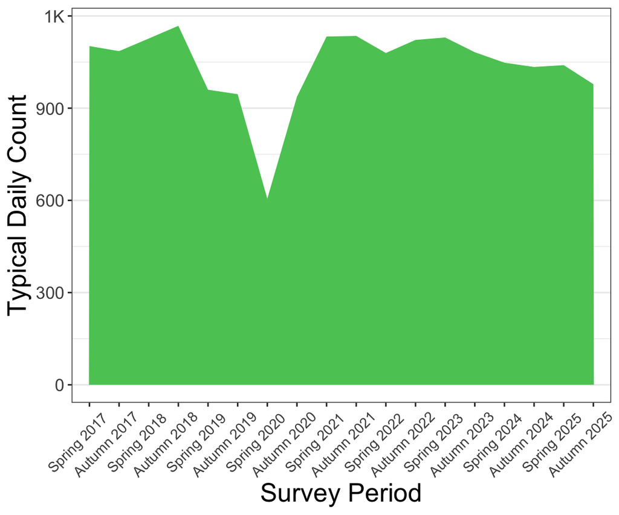

### HGV

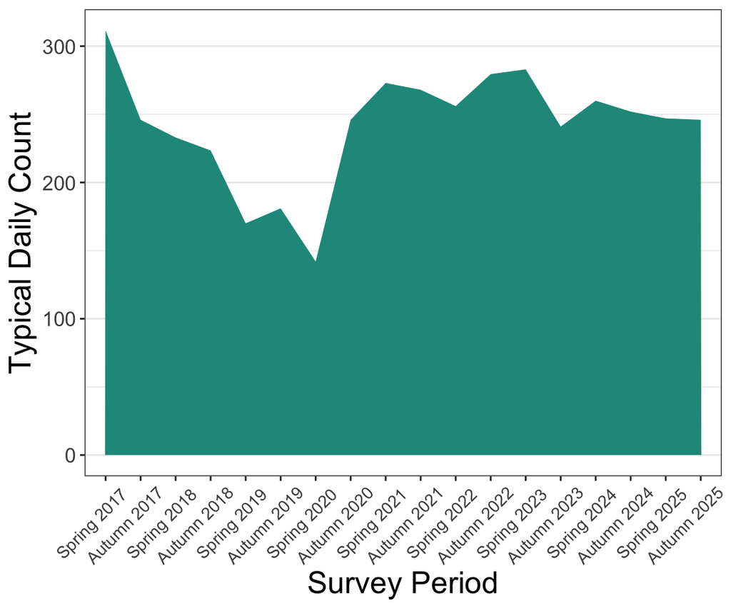

### Service Bus

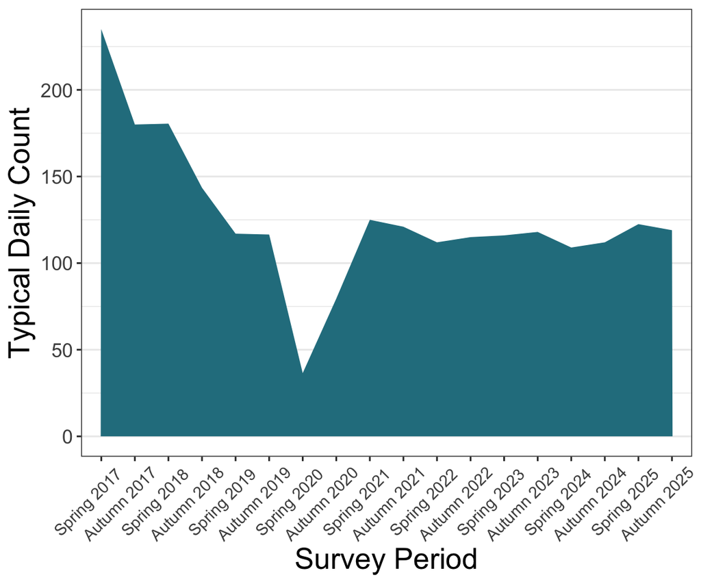

### Taxi

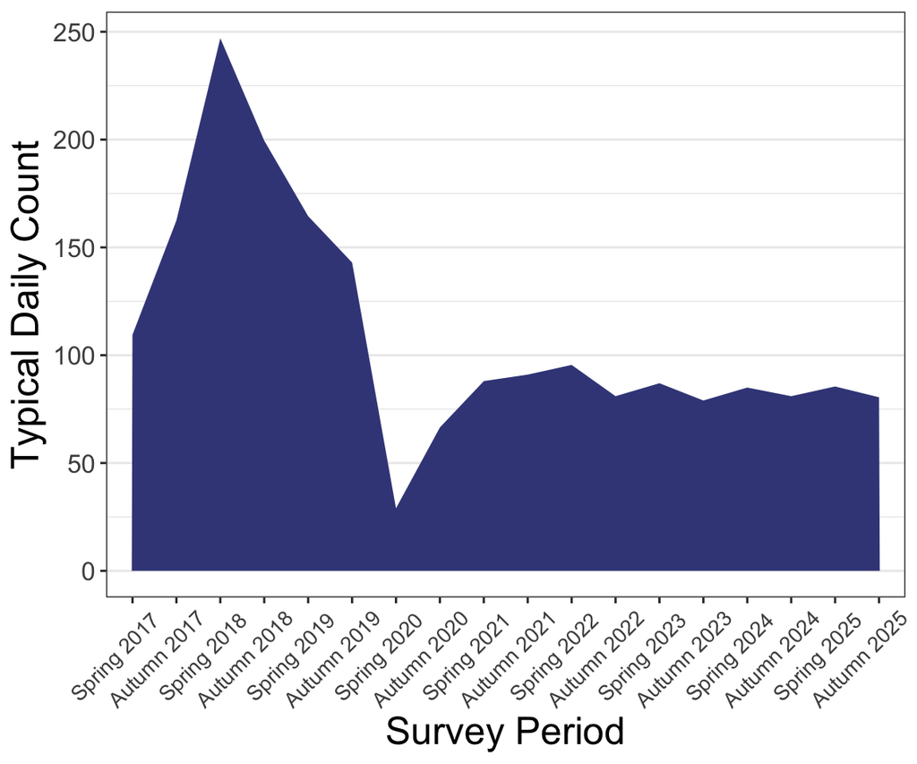

### Motorcycle

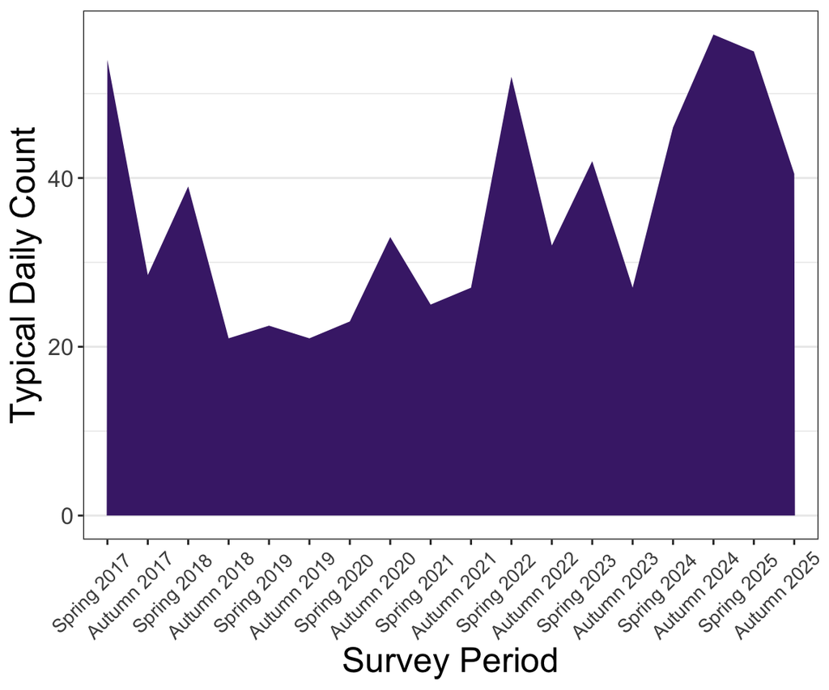

### Coach

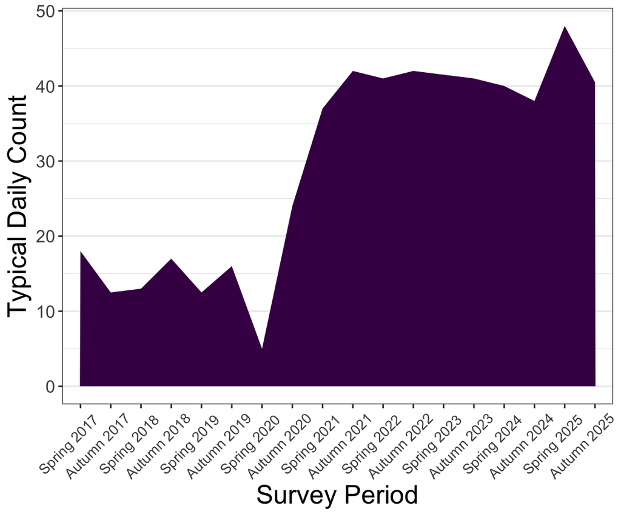

### Pedestrian

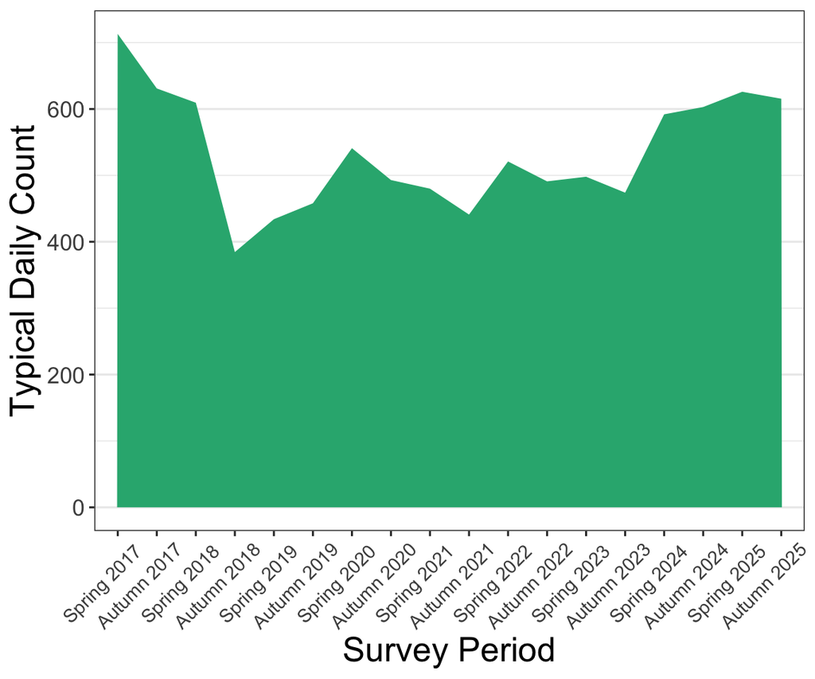

### Cyclist

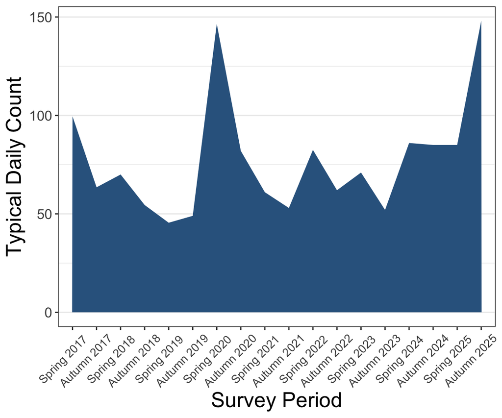

# Daily Patterns – All Transportation Modes

> Typical counts (median) across all survey locations compared to the average and totals, to distinguish between growth for any transportation mode and an increase in number of locations included in the survey. Looking at both medians (more typical) and means (averages) accounts for potential skew in traffic count and transportation mode due to road type and location.

### Change in Transportation Mode over Time

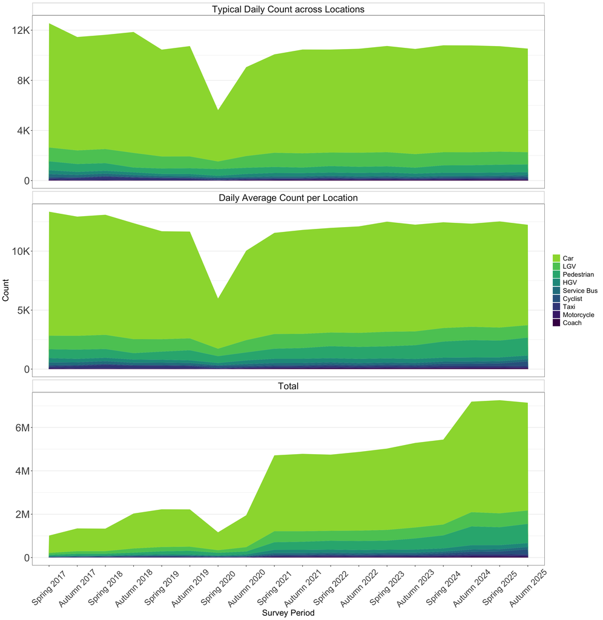

### Change in Count Locations over Time

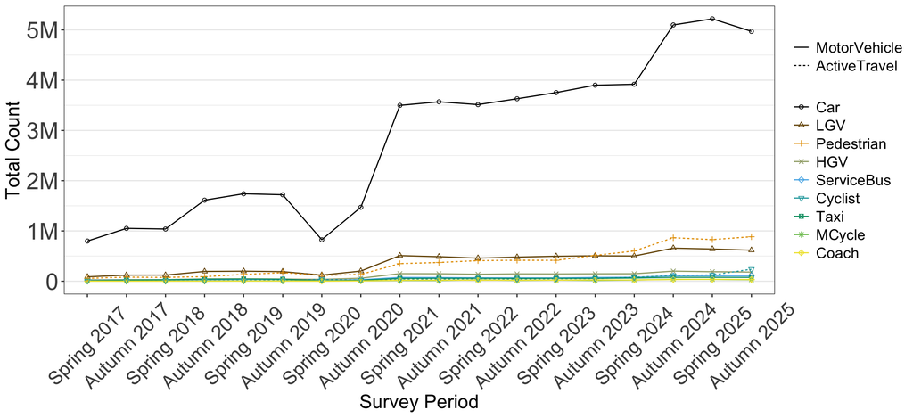

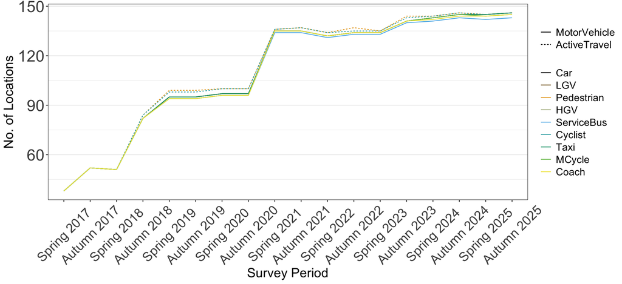

# Daily Patterns – Cycling

### Typical Daily Count across Locations – Cycling

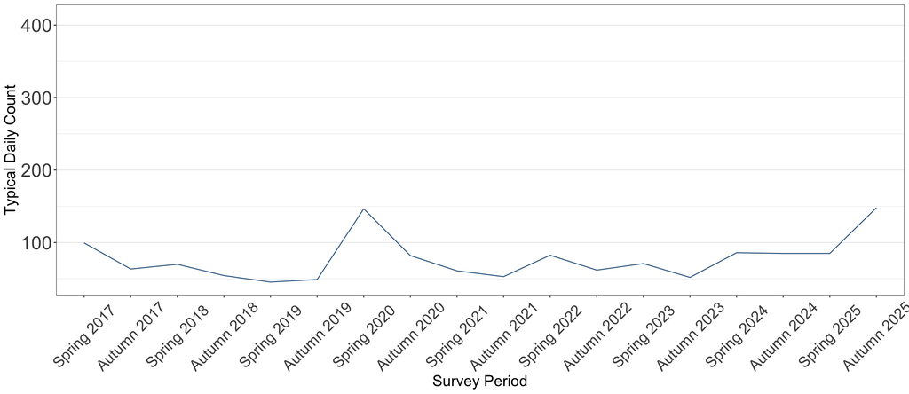

### Daily Average Count per Location – Cycling

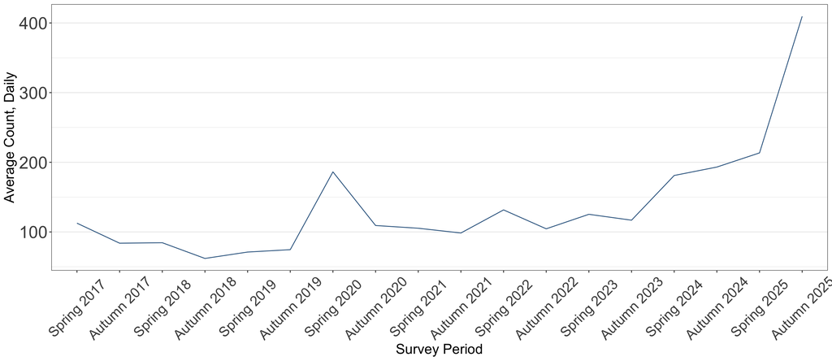

### Total Count – Cycling

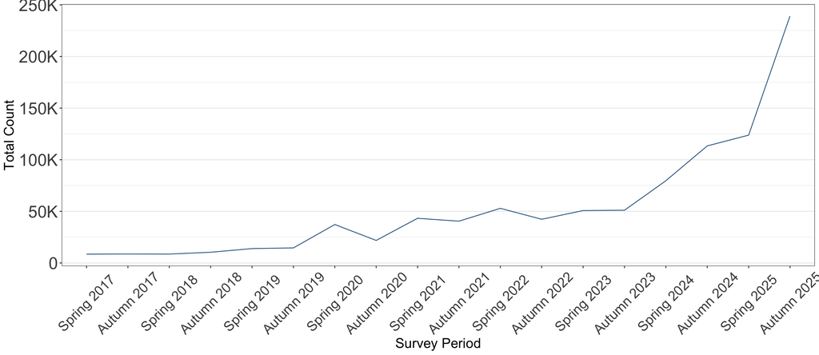

### No. of Locations – Cycling

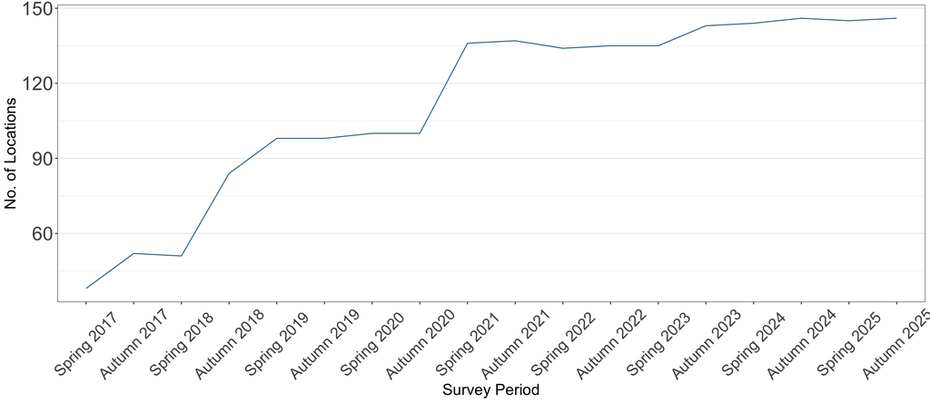